# Twitter Post Classification

[figure not shown]

## 👋🏼 **Introduction**

I got recently hired into a data analytics company. And my company are exploring into the field of NLP. And right now their focus is building a text classification model. Specifically, they want me to build them a NLP pipeline where it wants me to categorize the tweets as suicide related or not suicide related. The problem that currently we are facing is that there are many people on twitter which is now X, where they do now have someone to talk to when they get suicidical taughts. They generally pen down their taughts online. So our company want to help these people someone. And first problem that we have to we do not have model which can predict this wethere the tweets are related to suicide or not.

## 🧿 **Objective**

The objective of this project is that I will have to build a module which will try to classify the category of tweets. For this my company has given me a dataset which is in csv format. It has two columns, tweet and the suicide. Suicide column has labels whether the tweets are suicidical or not. So I will be using these data in the csv file and building an NLP model. Firstly I will be going through the full csv dataset and trying to remove the unwanted data. And then using these data I will be building a model. I will also be doing several experiments in order to improve the performance of the model. I will check if our dataset is balanced and if there is a requirement to increase the dataset so that our model can learn better from the data. Then I will choose the best-performing model to build my final model with the best-suited parameters.

**About the data**  
This dataset contains 2 columns. This data set is from Kaggle. You can [**click here**](https://www.kaggle.com/datasets/aunanya875/suicidal-tweet-detection-dataset) to view the dataset on kaggle.

## **NLP System Design**

[figure not shown]

## 📖 **Notebook Navigation**

Note: In the below **System Design** you will find all the steps that I am following to build this nlp model. **You can click** on each step, and it will take you to those steps as **I have attatched hyperlink**

Also, there will be two buttons in each steps. i.e. 🔝 and 📜.

1. 🔝 will take you to the top of the notebook
2. 📜 will take you to Table of Content.

🔝

## 📜 System Design

- ⬇ **Importing Libraries**
- 📊 **Importing Dataset**
- 🗺️ **Exploring the dataset**
- 💭 **Observations**
- ⚙️ **Processing the tweets**
- 🔧 **Feature Engineering**
- 📐 **Evaluation metrics**
- 🗂️ **Selecting the best model for our dataset**
- 🎛️ **Hyper-Parameter Tuning**
- 🏁 **Final Model**
- 🔎 **Model Evaluation**
- 💡 **Conclusion**

## ⬇ Importing Libraries 🔝 📜

I start by importing the necessary libraries for my Exploratory Data Analysis tasks in Python.

```python
# standard
import re
import string
import warnings
import os

# 3rd party
import numpy as np
import pandas as pd
import nltk
import seaborn as sns
import matplotlib.pyplot as plt
import emoji
import optuna
from IPython.display import display

# pre-processing
from sklearn.model_selection import train_test_split
from sklearn.feature_extraction.text import TfidfVectorizer, CountVectorizer
from sklearn.preprocessing import LabelEncoder
from nltk.corpus import wordnet
from nltk.tokenize import word_tokenize
from nltk.stem import WordNetLemmatizer

# oversampling
from imblearn.over_sampling import SMOTE, ADASYN

# evaluation metrics
from sklearn.metrics import accuracy_score, f1_score, precision_score, recall_score,classification_report, confusion_matrix, ConfusionMatrixDisplay
from imblearn.metrics import geometric_mean_score

# models used
from sklearn.ensemble import GradientBoostingClassifier, RandomForestClassifier
from sklearn.linear_model import LogisticRegression
from xgboost import XGBClassifier
```

## 📊 Importing Dataset 🔝 📜

I will be using pandas read from csv to read the twitter data and then we will be conducting an eda on the data.

```python
dtst_dir = '/Users/jasonjoelpinto/Documents/GitHub/python-datascience-projects/016. sentiment_analysis_NLP_project/dataset/Suicide_Ideation_Dataset(Twitter-based).csv'
dtst = pd.read_csv(dtst_dir)
print(display(dtst.sample(5)))
```

|  | Tweet | Suicide |
| --- | --- | --- |
| 658 | After looking at the American suicide statisti... | Potential Suicide post |
| 1762 | I hate going into my rap zone cause then I thi... | Potential Suicide post |
| 233 | @drrnlvngstn can i have yours? clouds have com... | Not Suicide post |
| 723 | can't find any nice words for a .tel domain ht... | Not Suicide post |
| 593 | I feel sorry for my 64 followers, cause my pos... | Not Suicide post |

```
None
```

## 🗺️ Exploring the dataset 🔝 📜

```python
dtst.sample(5)
```

|  | Tweet | Suicide |
| --- | --- | --- |
| 1399 | @imjustcreative bless ya fella | Not Suicide post |
| 1424 | @SowaTheArrogant Well he was partially right! ... | Potential Suicide post |
| 838 | @jordandossett tell me about it! we're going t... | Not Suicide post |
| 698 | @gcoakley13,,2nd is 'i dont want to be here an... | Potential Suicide post |
| 321 | --&gt; @katyperry in June (28) in Portugal!! I... | Not Suicide post |

I can see that

1. Tweet column has lot of unwanted data. Which might make our model very slow and less efficient and effective. Which we need to delete.
2. Suicide column has string data which we need to change to 0 and 1.

```python
dtst.shape
```

```
(1787, 2)
```

There are 1787 rows of data which is good so that the model can learn better from the dataset.

```python
dtst.info()
```

```
<class 'pandas.core.frame.DataFrame'>
RangeIndex: 1787 entries, 0 to 1786
Data columns (total 2 columns):
 #   Column   Non-Null Count  Dtype
---  ------   --------------  -----
 0   Tweet    1785 non-null   object
 1   Suicide  1787 non-null   object
dtypes: object(2)
memory usage: 28.1+ KB
```

Info gives us information regarding whether there are null values or not etc. The datatype of of the columns in object here.

```python
null_percentage = {}
for column in dtst:
    null_percentage[column] = round(( ( dtst[column].isnull().sum() ) / len(dtst)) * 100,2)
np_dataset = pd.DataFrame( list( null_percentage.items() ),  columns=[  'column_name'  , 'null_percentage' ])
np_dataset
```

|  | column_name | null_percentage |
| --- | --- | --- |
| 0 | Tweet | 0.11 |
| 1 | Suicide | 0.00 |

```python
dtst["Suicide"].unique()
```

```
array(['Not Suicide post', 'Potential Suicide post '], dtype=object)
```

There are no unnessary entries too. Which is a good thing for us.

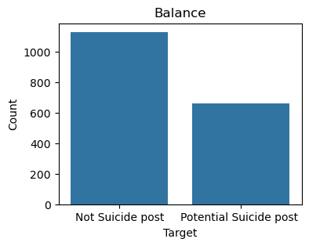

```python
cnt = dtst['Suicide'].value_counts()
plt.figure(figsize=(4, 3))
sns.barplot(x=cnt.index, y=cnt.values)
plt.title('Balance')
plt.xlabel('Target')
plt.ylabel('Count')
plt.show()
```

We can see that There are more Not suicide post, which is not a good sign for us, as we want the suicide posts to be detected more accurately.

## 💭 Observations 🔝 📜

Considering all these above points, I will be following the below steps to

**⚙️ pre-process**

1. 🗑️ Delete the null values
2. 🔄 Change the column values
3. 🔄 Convert the body to lower case
4. 🗑️ Remove hashtags
5. 🧹 Remove usertags
6. ‼️ Remove Punctuation
7. 🔢 Clear all numbers
8. 🀄️ Remove special characters
9. 🈲 Remove unwanted giberish characters
10. 🎍 Applying WordNet Lemmatizer for stemming
11. 🧮 Creating a TD-IDF matrix for the tweets
12. ➗ Splitting the data  
    I will be spliting datset into three parts, one for training, second one for validation and the third one for testing.

**🔧 feature Engineer**

1. 📈 Oversampling the data  
   Here as we saw there is heavy imbalance of the data. Hence it is necessary that I oversample the data. I will be using both adasyn and smote. And choosing which performs the best.

## ⚙️ Processing the tweets 🔝 📜

As I had mentioned already above we have a lot of cleaning to do on these dataset. So I will be walking you through the steps one by one.

1. We will clear all the unwanted tags, mentions, removing special characters, and removing numbers. There were also some giberish characters, which I will replacing with black entries.
2. Stemming will help us immensly to improve the performance of the model hence I will be stemming the tweets. For stemming I have choosen wordnet lammentizer because it performs the best even if it takes more time.
3. Then I will be applying TDIDF matrix on the dataset and joining it to the dataset.
4. And then untimately, I will be splitting the data into train,validation and test.

**1. 🗑️ Delete the null values**

```python
dtst = dtst.dropna()
dtst.head(5)
```

|  | Tweet | Suicide |
| --- | --- | --- |
| 0 | making some lunch | Not Suicide post |
| 1 | @Alexia You want his money. | Not Suicide post |
| 2 | @dizzyhrvy that crap took me forever to put to... | Potential Suicide post |
| 3 | @jnaylor #kiwitweets Hey Jer! Since when did y... | Not Suicide post |
| 4 | Trying out &quot;Delicious Library 2&quot; wit... | Not Suicide post |

**2. 🔄 Change the column values**

```python
dtst['Suicide'] = dtst['Suicide'].str.lower()
dtst['Suicide'] = dtst['Suicide'].str.replace(' ', '', regex=False)
def chg_col_vl(vl):
    if vl == 'notsuicidepost':
        return 0
    elif vl == 'potentialsuicidepost':
        return 1

dtst['Suicide'] =  dtst['Suicide'].apply(chg_col_vl)
dtst.head(5)
```

|  | Tweet | Suicide |
| --- | --- | --- |
| 0 | making some lunch | 0 |
| 1 | @Alexia You want his money. | 0 |
| 2 | @dizzyhrvy that crap took me forever to put to... | 1 |
| 3 | @jnaylor #kiwitweets Hey Jer! Since when did y... | 0 |
| 4 | Trying out &quot;Delicious Library 2&quot; wit... | 0 |

**3. 🔄 Convert the body to lower case**

```python
dtst['tweet_processed'] = dtst['Tweet'].str.lower()
dtst.head(5)
```

|  | Tweet | Suicide | tweet_processed |
| --- | --- | --- | --- |
| 0 | making some lunch | 0 | making some lunch |
| 1 | @Alexia You want his money. | 0 | @alexia you want his money. |
| 2 | @dizzyhrvy that crap took me forever to put to... | 1 | @dizzyhrvy that crap took me forever to put to... |
| 3 | @jnaylor #kiwitweets Hey Jer! Since when did y... | 0 | @jnaylor #kiwitweets hey jer! since when did y... |
| 4 | Trying out &quot;Delicious Library 2&quot; wit... | 0 | trying out &quot;delicious library 2&quot; wit... |

**4. #️⃣ Remove hashtags**

```python
dtst['tweet_processed'] = dtst[
                             'tweet_processed'
                             ].replace(
                                        r'#([^\s]+)', r'\1', regex=True
                                        )
dtst.head(5)
```

|  | Tweet | Suicide | tweet_processed |
| --- | --- | --- | --- |
| 0 | making some lunch | 0 | making some lunch |
| 1 | @Alexia You want his money. | 0 | @alexia you want his money. |
| 2 | @dizzyhrvy that crap took me forever to put to... | 1 | @dizzyhrvy that crap took me forever to put to... |
| 3 | @jnaylor #kiwitweets Hey Jer! Since when did y... | 0 | @jnaylor kiwitweets hey jer! since when did yo... |
| 4 | Trying out &quot;Delicious Library 2&quot; wit... | 0 | trying out &quot;delicious library 2&quot; wit... |

**5. 🧹 Remove usertags**

```python
dtst['tweet_processed'] = dtst['tweet_processed'].replace(r'@', '', regex=True)
dtst.head(5)
```

|  | Tweet | Suicide | tweet_processed |
| --- | --- | --- | --- |
| 0 | making some lunch | 0 | making some lunch |
| 1 | @Alexia You want his money. | 0 | alexia you want his money. |
| 2 | @dizzyhrvy that crap took me forever to put to... | 1 | dizzyhrvy that crap took me forever to put tog... |
| 3 | @jnaylor #kiwitweets Hey Jer! Since when did y... | 0 | jnaylor kiwitweets hey jer! since when did you... |
| 4 | Trying out &quot;Delicious Library 2&quot; wit... | 0 | trying out &quot;delicious library 2&quot; wit... |

**6.‼️ Remove Punctuation**

```python
def rem_punc(tweet):
    tweet = tweet.translate(str.maketrans('','',string.punctuation))
    return tweet

dtst['tweet_processed'] = dtst['tweet_processed'].apply(rem_punc)
dtst.head(5)
```

|  | Tweet | Suicide | tweet_processed |
| --- | --- | --- | --- |
| 0 | making some lunch | 0 | making some lunch |
| 1 | @Alexia You want his money. | 0 | alexia you want his money |
| 2 | @dizzyhrvy that crap took me forever to put to... | 1 | dizzyhrvy that crap took me forever to put tog... |
| 3 | @jnaylor #kiwitweets Hey Jer! Since when did y... | 0 | jnaylor kiwitweets hey jer since when did you ... |
| 4 | Trying out &quot;Delicious Library 2&quot; wit... | 0 | trying out quotdelicious library 2quot with mi... |

**7. 🔢 Clear all numbers**

```python
dtst['tweet_processed'] = dtst[
                            'tweet_processed'
                            ].replace(
                                        r'\d+', '', regex=True
                                        )
dtst.head(5)
```

|  | Tweet | Suicide | tweet_processed |
| --- | --- | --- | --- |
| 0 | making some lunch | 0 | making some lunch |
| 1 | @Alexia You want his money. | 0 | alexia you want his money |
| 2 | @dizzyhrvy that crap took me forever to put to... | 1 | dizzyhrvy that crap took me forever to put tog... |
| 3 | @jnaylor #kiwitweets Hey Jer! Since when did y... | 0 | jnaylor kiwitweets hey jer since when did you ... |
| 4 | Trying out &quot;Delicious Library 2&quot; wit... | 0 | trying out quotdelicious library quot with mix... |

**8. 🀄️ Remove special characters**

```python
dtst['tweet_processed'] = dtst['tweet_processed'].str.replace("[^a-zA-Z#]", " ")
dtst.head()
```

|  | Tweet | Suicide | tweet_processed |
| --- | --- | --- | --- |
| 0 | making some lunch | 0 | making some lunch |
| 1 | @Alexia You want his money. | 0 | alexia you want his money |
| 2 | @dizzyhrvy that crap took me forever to put to... | 1 | dizzyhrvy that crap took me forever to put tog... |
| 3 | @jnaylor #kiwitweets Hey Jer! Since when did y... | 0 | jnaylor kiwitweets hey jer since when did you ... |
| 4 | Trying out &quot;Delicious Library 2&quot; wit... | 0 | trying out quotdelicious library quot with mix... |

**9.🈲 Remove unwanted giberish characters**

```python
def rem_gib_space(twt):
    twt = twt.encode('ascii', 'ignore').decode('ascii')
    twt = re.sub(r'\s+', ' ', twt).strip()
    return twt

dtst['tweet_processed'] = dtst['tweet_processed'].apply(rem_gib_space)
dtst.head(5)
```

|  | Tweet | Suicide | tweet_processed |
| --- | --- | --- | --- |
| 0 | making some lunch | 0 | making some lunch |
| 1 | @Alexia You want his money. | 0 | alexia you want his money |
| 2 | @dizzyhrvy that crap took me forever to put to... | 1 | dizzyhrvy that crap took me forever to put tog... |
| 3 | @jnaylor #kiwitweets Hey Jer! Since when did y... | 0 | jnaylor kiwitweets hey jer since when did you ... |
| 4 | Trying out &quot;Delicious Library 2&quot; wit... | 0 | trying out quotdelicious library quot with mix... |

**10. 🎍 Applying WordNet Lemmatizer for stemming**

```python
def lemmatize_text(text):
    lemmatizer = WordNetLemmatizer()
    lemmatized_tokens = []
    for word in nltk.word_tokenize(text):
        lemma = lemmatizer.lemmatize(word, pos='v')
        lemmatized_tokens.append(lemma)
    return ' '.join(lemmatized_tokens)


dtst['tweet_processed'] = dtst['tweet_processed'].apply(lemmatize_text)
dtst.head(5)
```

|  | Tweet | Suicide | tweet_processed |
| --- | --- | --- | --- |
| 0 | making some lunch | 0 | make some lunch |
| 1 | @Alexia You want his money. | 0 | alexia you want his money |
| 2 | @dizzyhrvy that crap took me forever to put to... | 1 | dizzyhrvy that crap take me forever to put tog... |
| 3 | @jnaylor #kiwitweets Hey Jer! Since when did y... | 0 | jnaylor kiwitweets hey jer since when do you s... |
| 4 | Trying out &quot;Delicious Library 2&quot; wit... | 0 | try out quotdelicious library quot with mix re... |

**11. 🧮 Creating a TD-IDF matrix for the tweets**

```python
trm_mdl = TfidfVectorizer(min_df=2)
m3 = trm_mdl.fit_transform(dtst['tweet_processed'])
inf = pd.DataFrame(m3.toarray(), index=dtst.index)
dtst = dtst.join(inf)
inverted_index = {id: term for term, id in trm_mdl.vocabulary_.items()}
```

**12. ➗ Splitting the data**

```python
tr = dtst['Suicide'].values
tr = tr.astype(float)

ft = dtst.drop(columns=[
                        'Tweet',
                        'tweet_processed',
                        'Suicide'
                        ])
```

```python
print(f'No of features     : {ft.shape[1]}')
print(f'Total rows of data : {ft.shape[0]}')
```

```
No of features     : 1675
Total rows of data : 1785
```

```python
ft_train_df,  ft_val_test_df,   tr_train_df,  tar_val_test_df = sklearn.model_selection.train_test_split(  ft , tr  ,  test_size = 0.35, shuffle=True, stratify=tr, random_state  =  40)
ft_val_df,  ft_test_df,   tar_val_df,  tar_test_df = sklearn.model_selection.train_test_split(  ft_val_test_df , tar_val_test_df  ,  test_size = 0.50,shuffle=True, stratify=tar_val_test_df,random_state  =  40)

print(f'Train features shape     : {ft_train_df.shape}')
print(f'Train target shape       : {tr_train_df.shape}')
print(39*'=')
print(f'Validation features shape: {ft_val_df.shape}')
print(f'Validation target shape  : {tar_val_df.shape}')
print(39*'=')
print(f'Test features shape      : {ft_test_df.shape}')
print(f'Test target shape        : {tar_test_df.shape}')
print(39*'=')
```

```
Train features shape     : (1160, 1675)
Train target shape       : (1160,)
=======================================
Validation features shape: (312, 1675)
Validation target shape  : (312,)
=======================================
Test features shape      : (313, 1675)
Test target shape        : (313,)
=======================================
```

## 🔧 Feature Engineering 🔝 📜

Here I will be oversampling the data as our dataset is heavily imbalanced. I will be storing all in three different pairs of variable.  
This is so that I can compare if model withould oversampling or with smote oversampling or with adasyn oversampling performs the best. And we will choose the best performing one out of them.

**1. 📈 Oversampling the data**

Applying **SMOTE** oversampling to the dataset

```python
mod_smt =  SMOTE(  )
ft_train_df_smt, tr_train_df_smt   =    mod_smt.fit_resample(
                                                            ft_train_df,
                                                            tr_train_df)

print("fet_train_smot size :",ft_train_df_smt.shape)
print("tar_train_smot size :",tr_train_df_smt.shape)
```

```
fet_train_smot size : (1464, 1675)
tar_train_smot size : (1464,)
```

Applying **ADASYN** oversampling to the dataset

```python
mod_adc =  ADASYN(  )
ft_train_df_adc, tr_train_df_adc   =    mod_adc.fit_resample(
                                                            ft_train_df,
                                                            tr_train_df)

print("fet_train_smot size :",ft_train_df_adc.shape)
print("tar_train_smot size :",tr_train_df_adc.shape)
```

```
fet_train_smot size : (1526, 1675)
tar_train_smot size : (1526,)
```

## 📐 Evaluation metrics 🔝 📜

**Primary: G-Mean & F1 score**  
For my model my primary metrics will be G-mean and f1 score as our dataset is imbalanced.  
These will give us balanced metrics of how our model performs for both positive and negetive labels.

**Secondary: Precision & F1 Recall**  
Secondary metrics will be precision and recall because I want to get a better idea for how it performs for false positive and and false negetive.  
These parameters will give me better view of that.

## 🗂️ Selecting the best model 🔝 📜

For model selection I have choose four of the best classification model. I will be running througha loop and finding the model which will give us the best gmean and f1 score

```python
log_reg = sklearn.linear_model.LogisticRegression()
svc = sklearn.svm.SVC()
ran_for_cls =  sklearn.ensemble.RandomForestClassifier()
xg_bst = XGBClassifier()
```

```python
def evaluate_model(ml, trf, trl, vlf, vll, mtd):
        ml.fit(trf, trl)
        p = pd.Series(ml.predict(vlf))
        return [
            mtd,
            ml.__class__.__name__,
            geometric_mean_score(vll, p),
            f1_score(vll, p),
            precision_score(vll, p),
            recall_score(vll, p),
            accuracy_score(vll, p)
                ]

mt_vl_lts = []
lt = [log_reg,svc,ran_for_cls,xg_bst]
cmb = [
        ('IM', ft_train_df, tr_train_df),
        ('SM', ft_train_df_smt, tr_train_df_smt),
        ('AD', ft_train_df_adc, tr_train_df_adc)
        ]
for ml in lt:
    for mtd, trf, trl in cmb:
        mt_vl_lt = evaluate_model(ml, trf, trl, ft_val_df, tar_val_df, mtd)
        if mt_vl_lt:
            mt_vl_lts.append(mt_vl_lt)
mt_vl_lts = pd.DataFrame(mt_vl_lts, columns=['Method', 'Model Name', 'G-mean','F1','PRE','REC', 'ACC'])
mt_vl_lts = mt_vl_lts.sort_values(ascending=False, by=['G-mean','F1','PRE','REC', 'ACC'])

display(mt_vl_lts.head(30))

print('\n')
print('*****'*15)
bm_name = mt_vl_lts.head(1)['Model Name'].values[0]
osty = mt_vl_lts.head(1)['Method'].values[0]
print(f'The best performing model is  :{bm_name} with oversampling method : {osty}')
print('*****'*15)

model_mapping = {
    'LogisticRegression': LogisticRegression,
    'SVC': SVC,
    'RandomForestClassifier': RandomForestClassifier,
    'XGBClassifier': XGBClassifier
}
bm = model_mapping[bm_name]
```

|  | Method | Model Name | G-mean | F1 | PRE | REC | ACC |
| --- | --- | --- | --- | --- | --- | --- | --- |
| 10 | SM | XGBClassifier | 0.864208 | 0.831858 | 0.846847 | 0.817391 | 0.878205 |
| 1 | SM | LogisticRegression | 0.861983 | 0.830357 | 0.853211 | 0.808696 | 0.878205 |
| 2 | AD | LogisticRegression | 0.861522 | 0.826087 | 0.826087 | 0.826087 | 0.871795 |
| 8 | AD | RandomForestClassifier | 0.853725 | 0.834951 | 0.945055 | 0.747826 | 0.891026 |
| 6 | IM | RandomForestClassifier | 0.850305 | 0.835821 | 0.976744 | 0.730435 | 0.894231 |
| 9 | IM | XGBClassifier | 0.850305 | 0.818182 | 0.857143 | 0.782609 | 0.871795 |
| 11 | AD | XGBClassifier | 0.843242 | 0.809091 | 0.847619 | 0.773913 | 0.865385 |
| 7 | SM | RandomForestClassifier | 0.841539 | 0.819512 | 0.933333 | 0.730435 | 0.881410 |
| 3 | IM | SVC | 0.833634 | 0.811881 | 0.942529 | 0.713043 | 0.878205 |
| 4 | SM | SVC | 0.833634 | 0.811881 | 0.942529 | 0.713043 | 0.878205 |
| 5 | AD | SVC | 0.833634 | 0.811881 | 0.942529 | 0.713043 | 0.878205 |
| 0 | IM | LogisticRegression | 0.824209 | 0.798030 | 0.920455 | 0.704348 | 0.868590 |

```
The best performing model is  :XGBClassifier with oversampling method : SM
```

here I am dynamically selecting the datasets based on our previous performance.

```python
tuning_dsets = {
    'AD': {'X': ft_train_df_adc, 'y': tr_train_df_adc},
    'SM': {'X': ft_train_df_smt, 'y': tr_train_df_smt},
    'IM': {'X': ft_train_df, 'y': tr_train_df},
}
ft = tuning_dsets[osty]['X']
tr = tuning_dsets[osty]['y']
```

[output not shown]

## 🎛️ Hyperparameter Tuning 🔝 📜

Let us tune the hyperparameters for `XGBClassifier` model and `SMOTE` dataset. Generally gridsearch cv is used for hyper parameter tuning. But here I will be using Optuna for the hyperparameter tuning because it is one of the best tuning models. It consumes are lot of resources to pick the best one. But makes the best pick and it does most of the hard work for us. Here I will be tuning below mentioned parameters. Let's see what we get

1. n_estimators
2. max_depth
3. min_child_weight
4. learning_rate
5. gamma
6. subsample
7. reg_alpha

I will be keeping the trial as 200 times so that it can keep on experimenting for the best combnination

```python
def hyptune(t):
    prs = {
        'objective': 'binary:logistic',
        'n_estimators': trial.suggest_int('n_estimators', 80, 950),
        'max_depth': trial.suggest_int('max_depth', 2, 9),
        'min_child_weight': trial.suggest_int('min_child_weight', 2, 9),
        'learning_rate': trial.suggest_float('learning_rate', 0.01, 0.1, log=True),
        'gamma': trial.suggest_float('gamma', 0.0, 5.0),
        'subsample': trial.suggest_float('subsample', 0.5, 1.0, step=0.1),
        'booster': 'gbtree',
        'reg_alpha': trial.suggest_float('reg_alpha', 0.0, 2.0)
            }

    hyml = bm(**prs, use_label_encoder=False)
    hyml.fit(ft, tr)
    hyp = hyml.predict(ft_val_df)
    gm  = geometric_mean_score(tar_val_df, hyp)
    fs  = f1_score(tar_val_df, hyp)
    pre = precision_score(tar_val_df, hyp)
    rec = recall_score(tar_val_df, hyp)
    return gm

optuna.logging.set_verbosity(optuna.logging.WARNING)
lrn = optuna.create_study(direction='maximize')
lrn.optimize(objective, n_trials=200)
bt = lrn.best_trial.value
bp = lrn.best_trial.params
print(f'No of trials             : {200}')
print(f'Overscaling type         : {osty}')
print(f'Top gmean score          : {bt}')
print(f'Top performing parameters: {bp}')
```

[output not shown]

As we can see here our best performing trial got a score of 0.87.  
Which is almost 1 percent higher than previous.  
Which is great!!  
And the parametars also mentioned above.

## 🏁 Final Model 🔝 📜

Let's train the final model, and check how our model performs.....

```python
display(print(bp))
display(print(bm))
```

[output not shown]

```
None
```

```
<class 'xgboost.sklearn.XGBClassifier'>
```

```
None
```

```python
bp = study.best_trial.params
fim = bm(**bp, use_label_encoder=False)
fim.fit(ft, tr)
fip = fim.predict(ft_test_df)
fgm  = geometric_mean_score(tar_test_df, fip)
ffs  = f1_score(tar_test_df, fip)
fpre = precision_score(tar_test_df, fip)
frec = recall_score(tar_test_df, fip)

print(f'G-Mean Score: {fgm}')
print(f'F1 Score    : {ffs}')
print(f'Precision   : {fpre}')
print(f'Recall      : {frec}')
```

```
G-Mean Score: 0.8909320097321356
F1 Score    : 0.8699551569506726
Precision   : 0.9065420560747663
Recall      : 0.8362068965517241
```

## 🔎 Model Evaluation 🔝 📜

Classification report

```python
print(classification_report(tar_test_df, fip))
```

```
              precision    recall  f1-score   support

         0.0       0.91      0.95      0.93       197
         1.0       0.91      0.84      0.87       116

    accuracy                           0.91       313
   macro avg       0.91      0.89      0.90       313
weighted avg       0.91      0.91      0.91       313
```

```
<sklearn.metrics._plot.confusion_matrix.ConfusionMatrixDisplay at 0x35a7bb110>
```

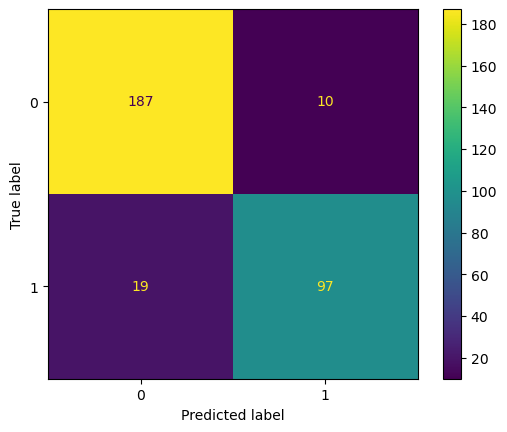

```python
ConfusionMatrixDisplay(confusion_matrix(tar_test_df, fip)).plot()
```

## 💡 Conclusion 🔝 📜

In conclusion, the main aim of this pipeline is to classify the tweets into two categories such as suicidal and non-suicidal. The essential step for this classification includes importing the given dataset, exploring, experimenting with various model, training and hypertuning the models and eventually determining the best model.  
The target label for the given dataset is 'suicide' which have values 0 and 1 where 0 represents 'non-suicidal' and 1 represents 'suicidal'.  
While doing EDA many unwanted data were discovered. Hence, preprocessing the unwanted data was cleaned.  
For stemming the words WordNet Lemmatizer was used due to it's good accuracy. Further, TF-IDF matrix was created and concatenated with the dataframe.  
Finally, the data was split into train, validation and test.  
Due to heavy imbalance in the data set, smote and adasyn techniques were used to oversample the data.

Next, for training, 4 models were selected for task, such as

1. Logistic Regression
2. SVM
3. Random Forest Classifier
4. XGBClassifier

All three sets (imbalanced, smote oversampled, adasyn oversamples) of dataset was run through these model to get the best performing mode.  
We found that XGBClassifier with SMOTE oversampling data performed the best with G-Mean of 0.864 and F1 score of 0.832  
This model is then tuned using Optuna Hypertuning.  
This gives us the best performing hyperparameters as 'n_estimators'= 592, 'max_depth'= 6, 'min_child_weight'= 3, 'learning_rate' 0.03786534038927119}

We use these parameters to train our final model. And we got the best result out of all the experiments we conduction with the results below  
G-Mean Score: 0.8909320097321356  
F1 Score : 0.8699551569506726  
Precision : 0.9065420560747663  
Recall : 0.8362068965517241

[Twitter](https://icons8.com/icon/68193/twitter) icon by [Icons8](https://icons8.com)